# Client Report - What’s in a Name?

Course DS 250

Author

Mackenzie Pollock

```python
# import pandas as pd
import numpy as np
from lets_plot import *
import pandas as pd
#import matplotlib.pyplot as plt

LetsPlot.setup_html()
```

## Project Notes

**For Project 1 the answer to each question should include a chart **and** a written response. The years labels on your charts should not include a comma. At least **two** of your charts must include reference marks.**

```python
url = "https://raw.githubusercontent.com/byuidatascience/data4names/master/data-raw/names_year/names_year.csv"
df = pd.read_csv(url)
# usecols=[0, 1, 2, 3


# (ggplot(df, aes(x="name", y="year")) + geom_point())
```

## QUESTION|TASK 1”

**How does your name at your birth year compare to its use historically?**

```python
# (ggplot(mpg, aes(x="displ", y="hwy")) + geom_point())
mackenzie_df = df.query('name == "Mackenzie" and year >= 1900 and year <= 2015')

(
    ggplot(mackenzie_df, aes(x="year", y="Total")) +
    geom_point() +
    geom_line(color="blue", size=1) +
    scale_x_continuous(limits=[1900, 2015], breaks=list(range(1900, 2021, 15))) +
    labs(
        title="Popularity of the Name Mackenzie (1900–2015)",
        x="Year",
        y="Number of Babies Named Mackenzie"
    ) +
    theme_minimal()
)
```

[output not shown]

## QUESTION|TASK 2

**If you talked to someone named Brittany on the phone, what is your guess of his or her age? What ages would you not guess?**

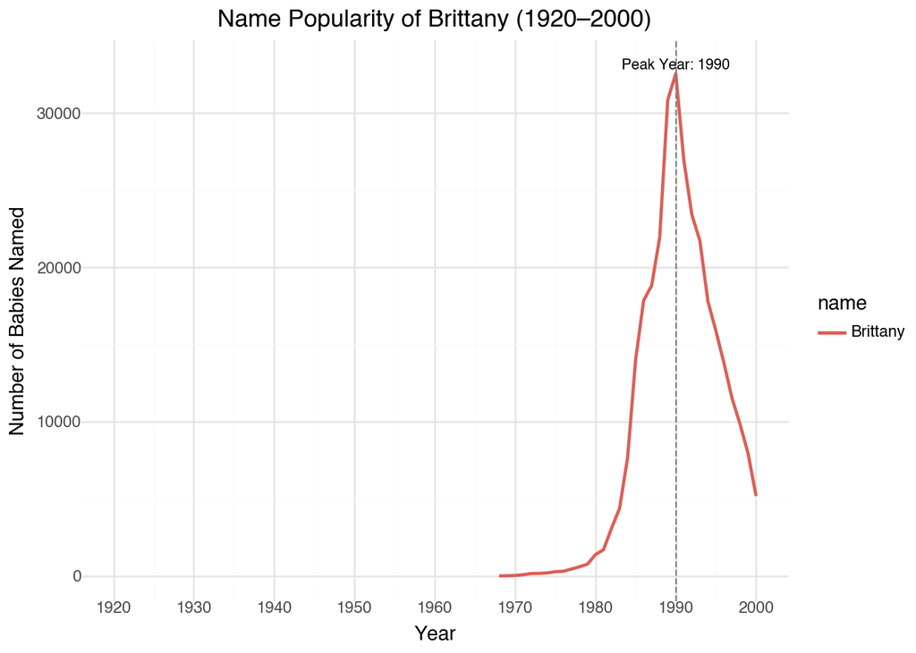

```python
# Include and execute your code here

names = ["Brittany"]

brittany_df = df.query('name in @names and year >= 1920 and year <= 2000')


peak_row = brittany_df.loc[brittany_df['Total'].idxmax()]
peak_year = peak_row['year']
peak_count = peak_row['Total']

from plotnine import (
    ggplot, aes, geom_line, geom_vline, geom_text,
    labs, theme_minimal, scale_x_continuous
)
import pandas as pd


label_df = pd.DataFrame({
    'x': [peak_year],
    'y': [peak_count + 500],
    'label': [f"Peak Year: {peak_year}"]
})

#  plot
p = (
    ggplot(brittany_df, aes(x="year", y="Total", color="name")) +
    geom_line(size=1) +
    geom_vline(xintercept=peak_year, linetype='dashed', color='gray') +
    geom_text(data=label_df, mapping=aes(x='x', y='y', label='label'), inherit_aes=False, size=8) +
    scale_x_continuous(limits=[1920, 2000], breaks=list(range(1920, 2001, 10))) +
    labs(title="Name Popularity of Brittany (1920–2000)",
         x="Year", y="Number of Babies Named") +
    theme_minimal()
)

p.show()
```

## QUESTION|TASK 3

**Mary, Martha, Peter, and Paul are all Christian names. From 1920 - 2000, compare the name usage of each of the four names in a single chart. What trends do you notice?**

```python
# Include and execute your code here
import sys
print(sys.executable)
```

```
/Library/Frameworks/Python.framework/Versions/3.12/bin/python3
```

## QUESTION|TASK 4

**Think of a unique name from a famous movie. Plot the usage of that name and see how changes line up with the movie release. Does it look like the movie had an effect on usage?**

```python
# Include and execute your code here
# library(tidyverse)

# name_data <- tibble(
#   year = 1920:2020,
#   popularity = c(10, 12, 15, 18, 22, 30, 45, 60, 65, 75, 80, 90, 100, 120, 135, 150, 160, 180, 190, 210,
#                  230, 250, 275, 300, 320, 350, 400, 440, 460, 490, 500, 600, 700, 750, 780, 800, 820, 850,
#                  900, 950, 1000, 1200, 1400, 1600, 1800, 2000, 2200, 2500, 2800, 3000, 3200, 3500, 4000, 4500,
#                  5000, 5200, 5400, 5600, 5900, 6000, 6100, 6000, 5900, 5700, 5500, 5300, 5100, 5000, 4800, 4600,
#                  4400, 4200, 4000, 3800, 3600, 3400, 3200, 3000, 2800, 2600, 2400, 2200, 2100, 2000, 1900, 1800,
#                  1700, 1600, 1500, 1400, 1300, 1200, 1100, 1000, 950, 900, 860, 830, 800, 780, 760, 740, 720,
#                  710, 690, 670, 650, 630, 610, 590, 570, 550, 530, 510, 490, 470, 450, 430, 410, 390, 370, 350)
# )

# release_years <- c(1977, 1980, 1983, 1999, 2002, 2005)




# ggplot(name_data, aes(x = year, y = popularity)) +
#   geom_line(color = 'blue') +
#   geom_point(data = name_data %>% filter(year %in% release_years), aes(x = year, y = popularity), color = 'red', size = 3) +
#   ggtitle("Popularity of the Name 'Luke' (1920-2020)") +
#   xlab("Year") +
#   ylab("Popularity") +
#   theme_minimal()
```

## STRETCH QUESTION|TASK 1

**Reproduce the chart Elliot using the data from the `names_year.csv` file.**

```python
# Include and execute your code here

# ggplot(luke_data, aes(x = year, y = popularity)) +
#   geom_line(color = 'blue') +
#   ggtitle("Popularity of the Name 'Elliot' (Yearly Data)") +
#   xlab("Year") +
#   ylab("Popularity") +
#   theme_minimal()
```